# R’da Dağılımlar, Hipotez Testleri, ANOVA, EKK

# 1 Olasılıkla İlgili Temel Fonksiyonlar

## 1.1 Kombinasyon sayısı

```r
choose(5, 3) # 5 eleman içerisinden 3 elemanı kaç şekilde seçebiliriz?
```

```
## [1] 10
```

## 1.2 Tüm kombinasyonlar

```r
items <- 2:5
k <- 2
combn(items, k)
```

```
##      [,1] [,2] [,3] [,4] [,5] [,6]
## [1,]    2    2    2    3    3    4
## [2,]    3    4    5    4    5    5
```

## 1.3 Rastgele Örneklem / Dizi Oluşturma

```r
x <- 1:10
x
```

```
##  [1]  1  2  3  4  5  6  7  8  9 10
```

```r
sample(x, 5)
```

```
## [1]  1  5  2 10  3
```

```r
sample(x, 5, replace = TRUE)
```

```
## [1] 10  3 10  8  3
```

```r
y <- c("H", "T")
sample(y, 10, replace = TRUE)
```

```
##  [1] "H" "H" "H" "H" "H" "H" "T" "T" "H" "T"
```

# 2 Dağılımlar

R’da dağılımlar hakkında bilgi almak için dört tür fonksiyon vardır:

- `d` fonksiyonları bir dağılımın pdf’ini verir
- `p` fonksiyonları bir dağılımın cdf’ini verir
- `q` fonksiyonları kuantilleri verir
- `r` fonksiyonları bir dağılımdan rastsal örneklem verir

## 2.1 Kesikli Dağılımlar için Olasılıkların Hesaplanması

Kesikli bir rastgele değişkenle ilişkili basit ($P(X = x)$) veya kümülatif olasılığı ($P(X \leq x)$) hesaplamak istiyorsanız, sırasıyla `d` ve `p` fonksiyonlarını kullanabilirsiniz.

Elimizde $X$ binom değişkenimiz olsun ve 10 deneme yaptığımızı varsayalım. Burada her denemenin başarı olasılığı 1/2’dir. “dbinom” fonksiyonunu çağırarak $x = 7$ gözlemleme olasılığını hesaplayabiliriz:

```r
dbinom(7, size = 10, prob = 0.5)
```

```
## [1] 0.1171875
```

$x = 7$ için kümülatif olasılık (yani $P(X \leq 7)$):

```r
pbinom(7, size = 10, prob = 0.5)
```

```
## [1] 0.9453125
```

| Dağılım | Yoğunluk Fonksiyonu | Dağılım Fonksiyonu |
| --- | --- | --- |
| Binom | `dbinom(x, size, prob)` | `pbinom(x, size, prob)` |
| Geometrik | `dgeom(x, prob)` | `pgeom(x, prob)` |
| Poisson | `dpois(x, lambda)` | `ppois(x, lambda)` |

## 2.2 Sürekli Dağılımlar için Olasılıkların Hesaplaması

| Dağılım | Dağılım Fonksiyonu |
| --- | --- |
| Normal | `pnorm(x, mean, sd)` |
| Student’s t | `pt(x, df)` |
| Üstel | `pexp(x, rate)` |
| Gamma | `pgamma(x, shape, rate)` |
| Ki Kare | `pchisq(x, df)` |

Bir erkeğin 166cmden kısa olma olasılığını hesaplamak için `pnorm`u kullanabiliriz. Erkeklerin boylarının normal olarak ortalama 177cm ve standart sapma 7cm ile dağıldığını varsayalım.

Matematiksel olarak ifade edersek $X \sim N(177, 7)$ veri iken $P(X \leq 166)$ değerini bulmaya çalışıyoruz:

```r
pnorm(166, mean = 177, sd = 7)
```

```
## [1] 0.05804157
```

## 2.3 Olasılıkları Kuantillere Dönüştürme

Veri bir olasılık $p$ ve dağılım için, $p$ için karşılık gelen kuantili ($x$) belirlemek istiyorsak, ($P(X \leq x) = p$), `q` fonksiyonlarını kullanabiliriz.

```r
qnorm(0.025)
```

```
## [1] -1.959964
```

```r
qnorm(0.975)
```

```
## [1] 1.959964
```

## 2.4 Yoğunluk Fonksiyonunun Çizilmesi

Bir olasılık dağılımının yoğunluk fonksiyonunu çizmek istiyorsanız, tanım kümesinde bir $x$ vektörü tanımlayabilirsiniz.

Dağılımın yoğunluk fonksiyonu $x$ değerine uygular ve ardından sonucu grafik şeklinde çizeriz.

$x$, tanım kümesinde bir noktalar vektörüyse, lognormal için `dlnorm` veya normal için `dnorm` gibi `d` yoğunluk fonksiyonlarından birini kullanarak yoğunluğu hesaplarız.

–3 ila +3 aralığı için standart normal dağılımı çizmek istediğimizi varsayalım:

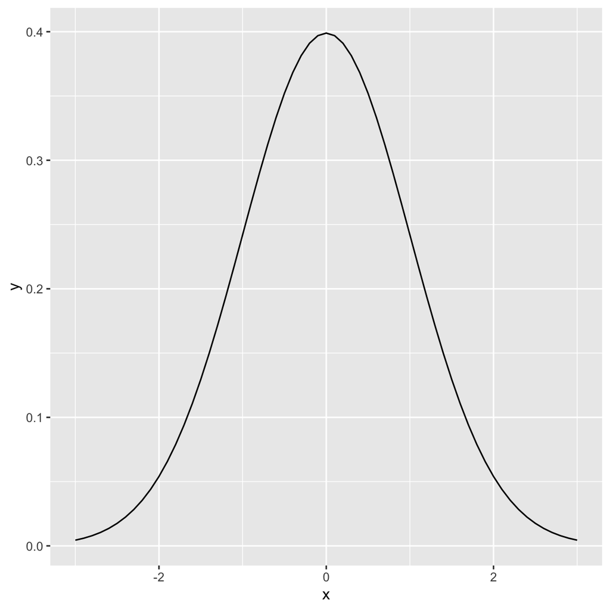

```r
library(tidyverse)

x <- seq(-3, 3, 0.1)

dens <- tibble(x = x,
               y = dnorm(x))

dens %>%
  ggplot() +
  aes(x, y) +
  geom_line()
```

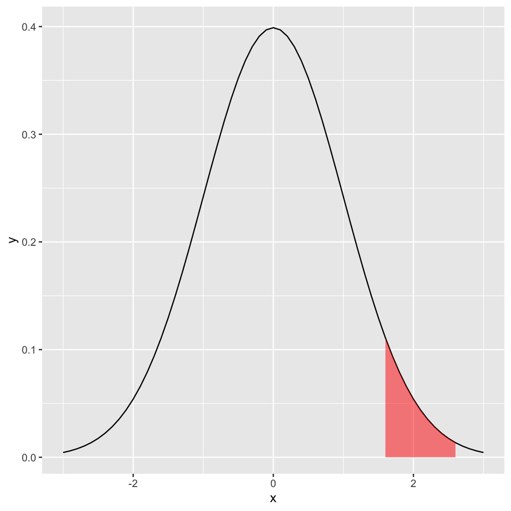

```r
# 75. yüzdelik dilimden 95.e kadar gölgelendirme ile normal dağılım.
dens %>%
  ggplot() +
  aes(x, y) +
  geom_line() +
  geom_ribbon(
    data = subset(dens, x > quantile(dens$x, .75) & x < quantile(dens$x, .95)),
    aes(ymax = y),
    ymin = 0,
    fill = "red",
    color = NA,
    alpha = 0.5)
```

## 2.5 İstatistiksel Dağılımlar ve Fonksiyonları

| Dağılım | Rastsal Sayı | Yoğunluk | Dağılım | Kuantil |
| --- | --- | --- | --- | --- |
| Normal | rnorm | dnorm | pnorm | qnorm |
| Binom | rbinom | dbinom | pbinom | qbinom |
| Poisson | rpois | dpois | ppois | qpois |
| t | rt | dt | pt | qt |
| F | rf | df | pf | qf |
| Ki Kare | rchisq | dchisq | pchisq | qchisq |
| Gamma | rgamma | dgamma | pgamma | qgamma |
| Geometrik | rgeom | dgeom | pgeom | qgeom |
| Negatif Binom | rnbinom | dnbinom | pnbinom | qnbinom |
| Üstel | rexp | dexp | pexp | qexp |
| Weibull | rweibull | dweibull | pweibull | qweibull |
| Tekdüze | runif | dunif | punif | qunif |
| Beta | rbeta | dbeta | pbeta | qbeta |
| Cauchy | rcauchy | dcauchy | pcauchy | qcauchy |
| Multinomial | rmultinom | dmultinom | pmultinom | qmultinom |
| Hipergeometrik | rhyper | dhyper | phyper | qhyper |
| Log-normal | rlnorm | dlnorm | plnorm | qlnorm |
| Lojistik | rlogis | dlogis | plogis | qlogis |

# 3 İstatistiksel Testler

## 3.1 Bağımsızlık için Kategorik Değişkenleri Test Etme

Faktörlerle temsil edilen iki kategorik değişken olduğunu ve Ki-kare testini kullanarak bağımsızlıklarını test etmek istediğimizi varsayalım.

```r
set.seed(42)
initial <- factor(sample(c("Yes", "No", "Maybe"), 100, replace = TRUE))
outcome <- factor(sample(c("Pass", "Fail"), 100, replace = TRUE))

table(initial, outcome) %>%
  summary()
```

```
## Number of cases in table: 100
## Number of factors: 2
## Test for independence of all factors:
##  Chisq = 0.030029, df = 2, p-value = 0.9851
```

Geleneksel olarak, 0,05’ten küçük bir p değeri, değişkenlerin muhtemelen bağımsız olmadığını gösterirken, 0,05’i aşan bir p değeri bu tür bir kanıtı sağlamada başarısız olur. Bu örnekte, büyük p değeri, iki faktörün, `initial` ve `outcome` muhtemelen bağımsız olduğunu gösterir.

## 3.2 Korelasyon ve Kovaryans

Daha önce korelasyonlarla birlikte güzel bir grafik çizen `GGally::ggpairs()` fonksiyonunu görmüştük.

```r
data("economics")
glimpse(economics)
```

```
## Rows: 574
## Columns: 6
## $ date     <date> 1967-07-01, 1967-08-01, 1967-09-01, 1967-10-01, 1967-11-01, …
## $ pce      <dbl> 506.7, 509.8, 515.6, 512.2, 517.4, 525.1, 530.9, 533.6, 544.3…
## $ pop      <dbl> 198712, 198911, 199113, 199311, 199498, 199657, 199808, 19992…
## $ psavert  <dbl> 12.6, 12.6, 11.9, 12.9, 12.8, 11.8, 11.7, 12.3, 11.7, 12.3, 1…
## $ uempmed  <dbl> 4.5, 4.7, 4.6, 4.9, 4.7, 4.8, 5.1, 4.5, 4.1, 4.6, 4.4, 4.4, 4…
## $ unemploy <dbl> 2944, 2945, 2958, 3143, 3066, 3018, 2878, 3001, 2877, 2709, 2…
```

```r
# pce & psavert arasındaki korelasyonu kontrol edelim
# pce kişisel tüketim harcamalarıdır
# psavert, kişisel tasarruf oranıdır.
economics %>%
  select(pce, psavert) %>%
  cor()
```

```
##                pce    psavert
## pce      1.0000000 -0.7928546
## psavert -0.7928546  1.0000000
```

```r
cor(economics$pce, economics$psavert)
```

```
## [1] -0.7928546
```

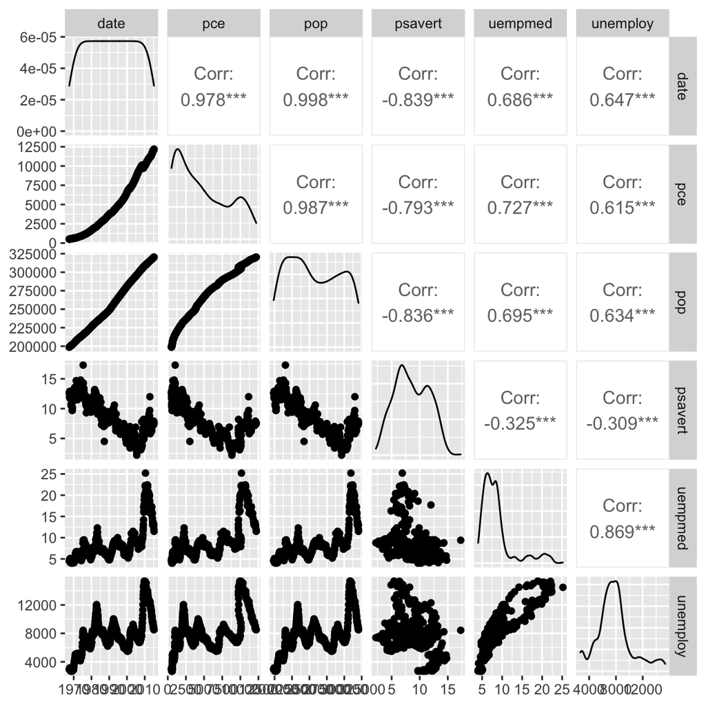

```r
GGally::ggpairs(economics)
```

Bir korelasyon ısı haritası (heatmap) oluşturalım.

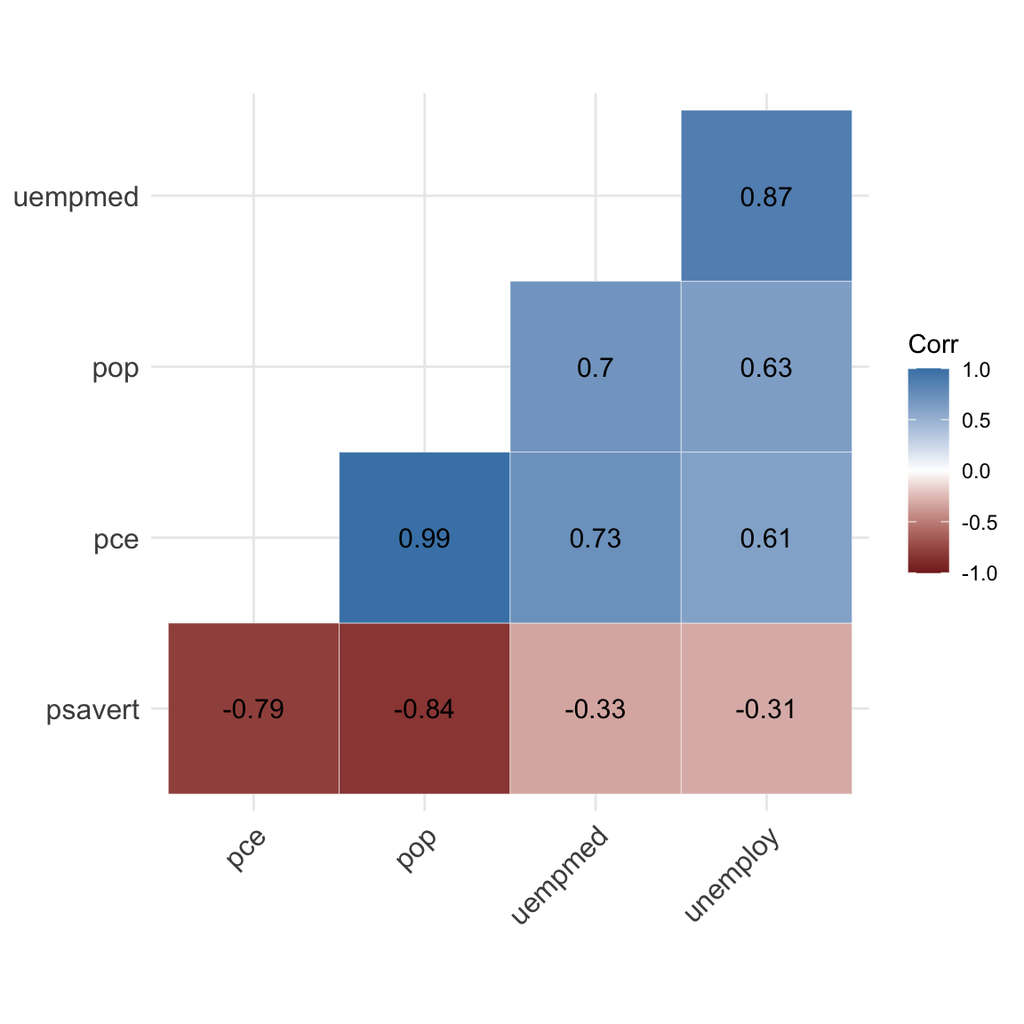

```r
library(ggcorrplot)

economics %>%
  select(-date) %>%
  cor() %>%
  round(2) %>%
  ggcorrplot(hc.order = TRUE,
             type = "lower",
             outline.color = "white",
             ggtheme = ggplot2::theme_minimal,
             colors = c(scales::muted("red"), "white", "steelblue"),
             lab = TRUE)
```

Kovaryans da korelasyona benzer.

```r
economics %>%
  select(-date) %>%
  cov()
```

```
##                    pce           pop       psavert       uempmed     unemploy
## pce       12650851.944  128807531.19  -8359.069071  10618.386190  5774578.978
## pop      128807531.194 1345598360.32 -90935.186145 104697.175892 61415622.243
## psavert      -8359.069     -90935.19      8.786360     -3.957847    -2422.805
## uempmed      10618.386     104697.18     -3.957847     16.864531     9431.652
## unemploy   5774578.978   61415622.24  -2422.805358   9431.652268  6979948.309
```

Korelasyon analizi yapmak için farklı yöntemler vardır:

- **Pearson korelasyonu**, iki değişken (x ve y) arasındaki doğrusal bir bağımlılığı ölçer. Verilerin dağılımına bağlı olduğu için parametrik korelasyon testi olarak da bilinir. **Yalnızca x ve y normal dağılımdan olduğunda kullanılabilir** .
- **Kendall tau** ve **Spearman rho**, sıra tabanlı korelasyon katsayılarıdır (parametrik olmayan).
- Kovaryasyon doğrusal mı?
- 2 değişkenin (x, y) her biri normal bir dağılım mı izliyor?

Korelasyon analizi yapmak için örnek bir veri seti kullanalım.

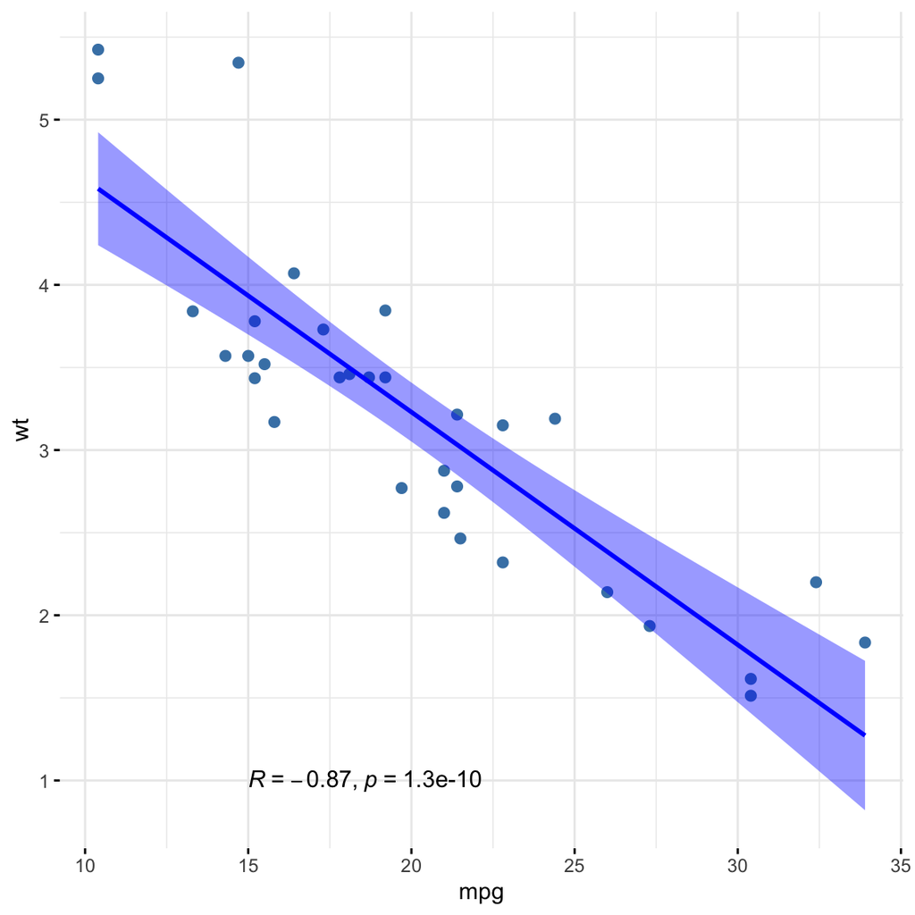

```r
library("ggpubr")

ggscatter(mtcars,
          x = "mpg",
          y = "wt",
          color = "steelblue",
          add = "reg.line",
          add.params = list(color = "blue"),
          conf.int = TRUE,
          cor.coef = TRUE,
          cor.coef.coord = c(15, 1),
          cor.method = "pearson",
          ggtheme = theme_minimal())
```

İlişki doğrusal gibi görünüyor. Normallik için Shapiro-Wilk testi yapalım. Boş hipotez, “veriler normal olarak dağılır” şeklindedir.

```r
shapiro.test(mtcars$mpg)
```

```
##
##  Shapiro-Wilk normality test
##
## data:  mtcars$mpg
## W = 0.94756, p-value = 0.1229
```

```r
shapiro.test(mtcars$wt)
```

```
##
##  Shapiro-Wilk normality test
##
## data:  mtcars$wt
## W = 0.94326, p-value = 0.09265
```

p değerleri 0.05 anlamlılık düzeyinden büyüktür, bu da verilerin dağılımının normal dağılımdan önemli ölçüde farklı olmadığını gösterir. Başka bir deyişle, normalliği varsayabiliriz.

Q-Q grafiklerini de kontrol edebiliriz. Bir Q-Q grafiği, iki kuantil kümesinin birbirine göre çizilmesiyle oluşturulan bir dağılım grafiğidir. Her iki kuantil kümesi de aynı dağılımdan geldiyse, kabaca düz bir çizgi oluşturan noktaları görmeliyiz.

Her iki kuantil kümesi gerçekten Normal dağılımlardan geldiğinde bir Normal Q-Q grafiği örneği şu şekildedir.

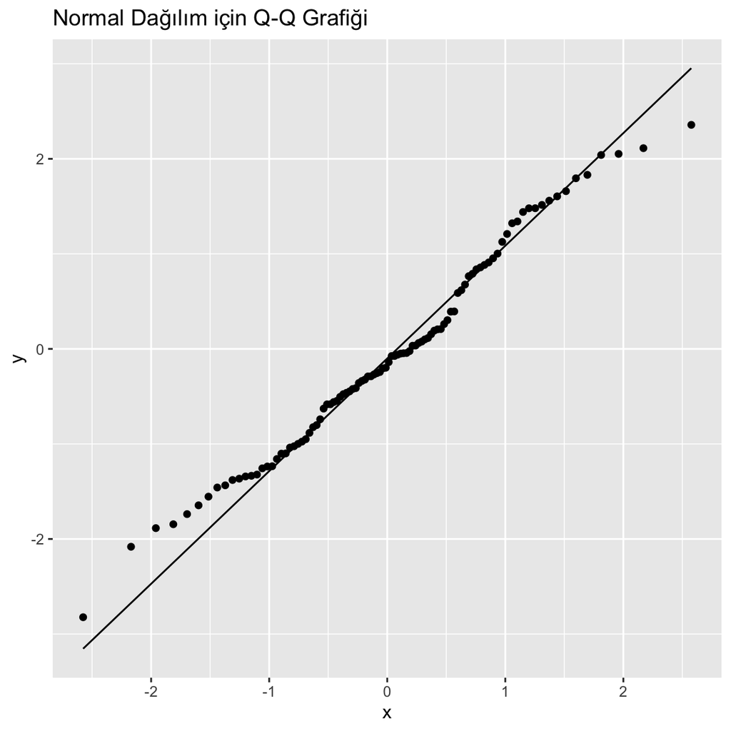

```r
tibble(x = rnorm(100)) %>%
  ggplot() +
  aes(sample = x) +
  stat_qq() +
  stat_qq_line() +
  labs(title = "Normal Dağılım için Q-Q Grafiği")
```

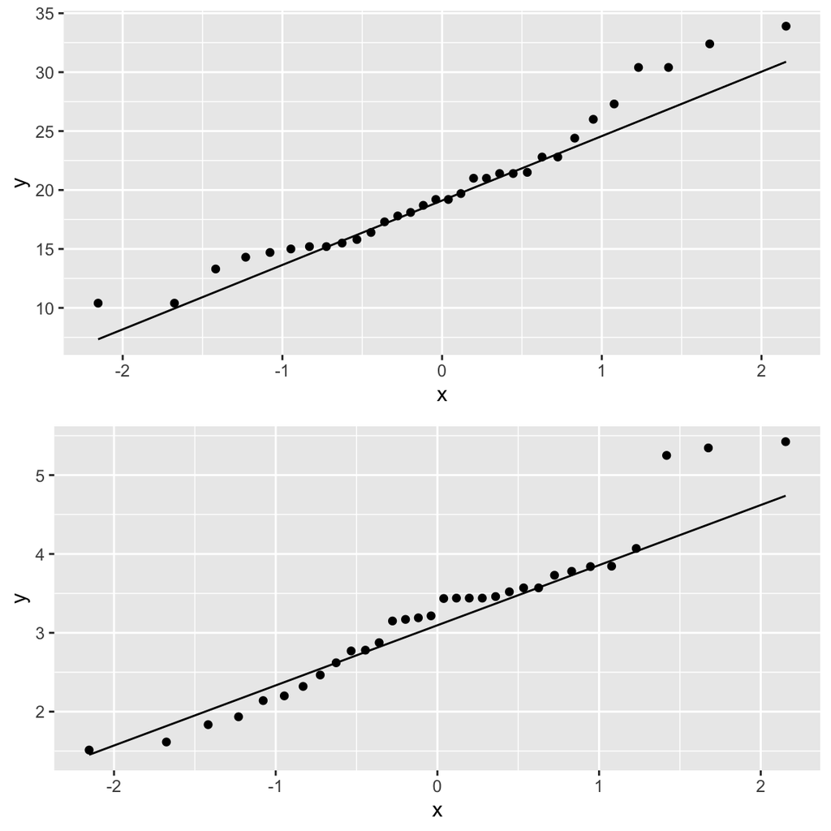

```r
p1 <- mtcars %>%
  ggplot(aes(sample = mpg)) +
  stat_qq() +
  stat_qq_line()

p2 <- mtcars %>%
  ggplot(aes(sample = wt)) +
  stat_qq() +
  stat_qq_line()


gridExtra::grid.arrange(p1, p2)
```

Şimdi Pearson korelasyon testi yapabiliriz.

```r
(ctres <- cor.test(mtcars$wt,
                  mtcars$mpg,
                  method = "pearson"))
```

```
##
##  Pearson's product-moment correlation
##
## data:  mtcars$wt and mtcars$mpg
## t = -9.559, df = 30, p-value = 1.294e-10
## alternative hypothesis: true correlation is not equal to 0
## 95 percent confidence interval:
##  -0.9338264 -0.7440872
## sample estimates:
##        cor
## -0.8676594
```

Testin p değeri 1.2939587^{-10}’dir, ki bu anlamlılık düzeyi $\alpha = 0.05$’ten küçüktür.

wt ve mpg’nin -0.8676594 korelasyon katsayısı ve 1.2939587^{-10} p-değeri ile önemli ölçüde ilişkili olduğu sonucuna varabiliriz.

**Her zaman verilerinizin grafiğini çizmelisiniz!!!**

```r
library(datasauRus)
glimpse(datasaurus_dozen)
```

```
## Rows: 1,846
## Columns: 3
## $ dataset <chr> "dino", "dino", "dino", "dino", "dino", "dino", "dino", "dino"…
## $ x       <dbl> 55.3846, 51.5385, 46.1538, 42.8205, 40.7692, 38.7179, 35.6410,…
## $ y       <dbl> 97.1795, 96.0256, 94.4872, 91.4103, 88.3333, 84.8718, 79.8718,…
```

```r
count(datasaurus_dozen, dataset)
```

```
## # A tibble: 13 × 2
##    dataset        n
##    <chr>      <int>
##  1 away         142
##  2 bullseye     142
##  3 circle       142
##  4 dino         142
##  5 dots         142
##  6 h_lines      142
##  7 high_lines   142
##  8 slant_down   142
##  9 slant_up     142
## 10 star         142
## 11 v_lines      142
## 12 wide_lines   142
## 13 x_shape      142
```

13 farklı veri setimiz var. Bu verilerdeki “dino” verilerini ve “x” ile “y” korelasyonlarını kontrol edelim.

```r
dino <- datasaurus_dozen %>%
  filter(dataset == "dino") %>%
  select(-dataset)

dino
```

```
## # A tibble: 142 × 2
##        x     y
##    <dbl> <dbl>
##  1  55.4  97.2
##  2  51.5  96.0
##  3  46.2  94.5
##  4  42.8  91.4
##  5  40.8  88.3
##  6  38.7  84.9
##  7  35.6  79.9
##  8  33.1  77.6
##  9  29.0  74.5
## 10  26.2  71.4
## # … with 132 more rows
```

```r
dino %>%
  cor()
```

```
##             x           y
## x  1.00000000 -0.06447185
## y -0.06447185  1.00000000
```

```r
(ctres <- cor.test(dino$x,
                  dino$y,
                  method = "pearson"))
```

```
##
##  Pearson's product-moment correlation
##
## data:  dino$x and dino$y
## t = -0.76443, df = 140, p-value = 0.4459
## alternative hypothesis: true correlation is not equal to 0
## 95 percent confidence interval:
##  -0.2267905  0.1013316
## sample estimates:
##         cor
## -0.06447185
```

**Korelasyon katsayısı, iki değişken arasındaki doğrusal ilişkiyi ölçer**.

Verilerimizin grafiğini çizelim ve ilişkinin doğrusal olup olmadığını görelim:

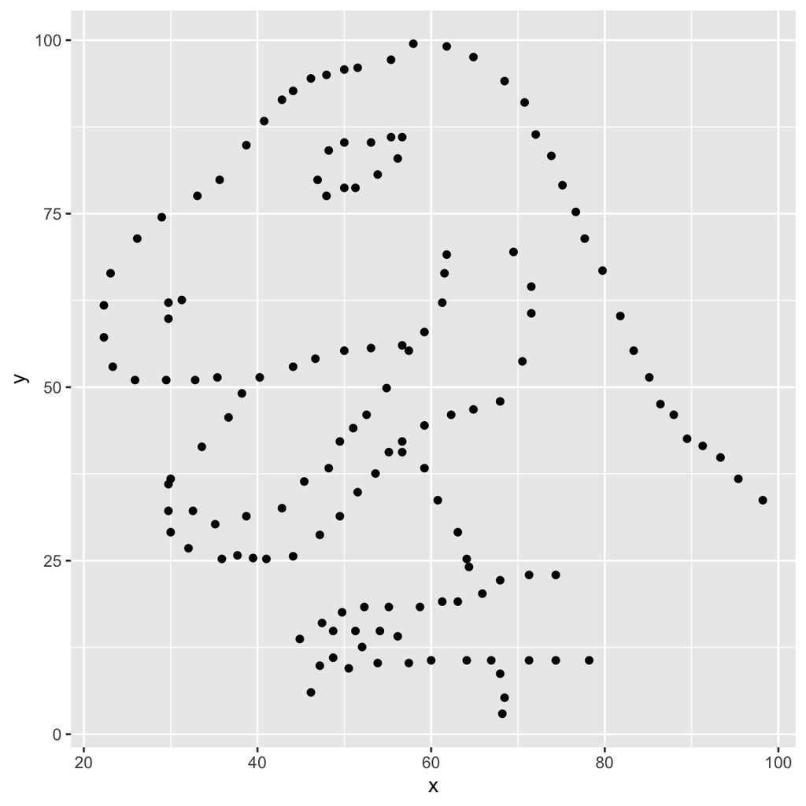

```r
ggplot(dino, aes(x = x, y = y)) +
  geom_point()
```

Gerçek hayatta, çizdiğimiz bazı değişken çiftleri arasında doğrusal bir ilişki yoktur.

İlişkinin biçimini değerlendirmek için görselleştirin ve yalnızca uygunsa korelasyonu hesaplayın.

Bu durumda, bir korelasyon katsayısının hesaplanması gerçekten mantıklı değildir, çünkü x ve y arasındaki ilişki kesinlikle doğrusal değildir - dinozoraldir!

Diğer tüm veri setlerini kontrol edelim.

```r
datasaurus_dozen %>%
  group_by(dataset) %>%
  summarise(mean_x = mean(x),
            mean_y = mean(y),
            sd_x = sd(x),
            sd_y = sd(y),
            cor_xy = cor(x, y))
```

```
## # A tibble: 13 × 6
##    dataset    mean_x mean_y  sd_x  sd_y  cor_xy
##    <chr>       <dbl>  <dbl> <dbl> <dbl>   <dbl>
##  1 away         54.3   47.8  16.8  26.9 -0.0641
##  2 bullseye     54.3   47.8  16.8  26.9 -0.0686
##  3 circle       54.3   47.8  16.8  26.9 -0.0683
##  4 dino         54.3   47.8  16.8  26.9 -0.0645
##  5 dots         54.3   47.8  16.8  26.9 -0.0603
##  6 h_lines      54.3   47.8  16.8  26.9 -0.0617
##  7 high_lines   54.3   47.8  16.8  26.9 -0.0685
##  8 slant_down   54.3   47.8  16.8  26.9 -0.0690
##  9 slant_up     54.3   47.8  16.8  26.9 -0.0686
## 10 star         54.3   47.8  16.8  26.9 -0.0630
## 11 v_lines      54.3   47.8  16.8  26.9 -0.0694
## 12 wide_lines   54.3   47.8  16.8  26.9 -0.0666
## 13 x_shape      54.3   47.8  16.8  26.9 -0.0656
```

Yani “özet istatistiklere asla güvenmeyin; verilerinizi daima görselleştirin.”

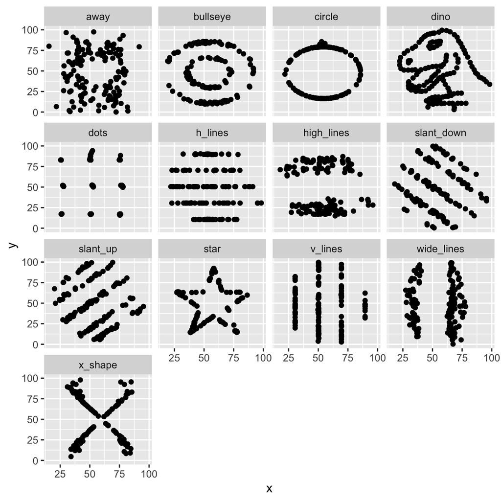

```r
ggplot(datasaurus_dozen, aes(x = x, y = y)) +
  geom_point() +
  facet_wrap(~dataset)
```

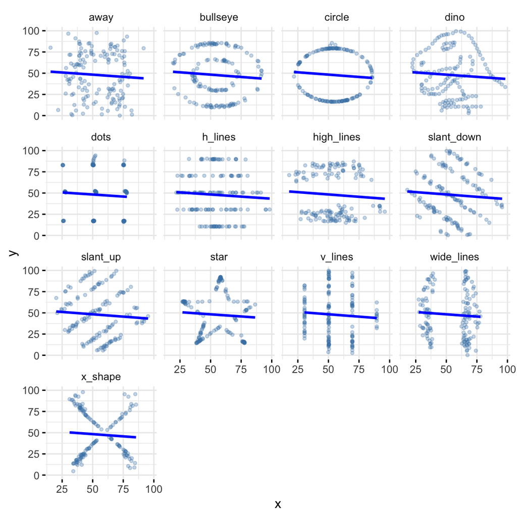

```r
ggscatter(datasaurus_dozen,
          x = "x",
          y = "y",
          color = "steelblue",
          alpha = 0.3,
          size = 1,
          add = "reg.line",
          add.params = list(color = "blue"),
          conf.int = FALSE,
          cor.method = "pearson",
          ggtheme = theme_minimal()) +
  facet_wrap(~dataset)
```